# Customer Segmentation for Retail

**Objective**: Segment customers based on purchasing behavior using clustering algorithms.

**Dataset**: Online Retail Dataset ([UCI Machine Learning Repository](https://archive.ics.uci.edu/ml/datasets/Online+Retail))

# Customer Segmentation for Retail

**Objective**: Segment customers based on purchasing behavior using clustering algorithms.

**Dataset**: Online Retail Dataset ([UCI Machine Learning Repository](https://archive.ics.uci.edu/ml/datasets/Online+Retail))

```python
pip install --upgrade seaborn pandas openpyxl
```

[output not shown]

## Step 1: Import Libraries

```python
# Import necessary libraries
import pandas as pd
import numpy as np
import matplotlib.pyplot as plt
import seaborn as sns
from sklearn.preprocessing import StandardScaler
from sklearn.cluster import KMeans, DBSCAN
from sklearn.decomposition import PCA
from sklearn.metrics import silhouette_score

import warnings
warnings.filterwarnings("ignore", category=FutureWarning)
```

## Step 2: Load the Dataset

```python
# Load the dataset
file_path = 'data/Online Retail.xlsx'
data = pd.read_excel(file_path)

print(data.shape)
# Display the first few rows
data.head()
```

```
(541909, 8)
```

|  | InvoiceNo | StockCode | Description | Quantity | InvoiceDate | UnitPrice | CustomerID | Country |
| --- | --- | --- | --- | --- | --- | --- | --- | --- |
| 0 | 536365 | 85123A | WHITE HANGING HEART T-LIGHT HOLDER | 6 | 2010-12-01 08:26:00 | 2.55 | 17850.0 | United Kingdom |
| 1 | 536365 | 71053 | WHITE METAL LANTERN | 6 | 2010-12-01 08:26:00 | 3.39 | 17850.0 | United Kingdom |
| 2 | 536365 | 84406B | CREAM CUPID HEARTS COAT HANGER | 8 | 2010-12-01 08:26:00 | 2.75 | 17850.0 | United Kingdom |
| 3 | 536365 | 84029G | KNITTED UNION FLAG HOT WATER BOTTLE | 6 | 2010-12-01 08:26:00 | 3.39 | 17850.0 | United Kingdom |
| 4 | 536365 | 84029E | RED WOOLLY HOTTIE WHITE HEART. | 6 | 2010-12-01 08:26:00 | 3.39 | 17850.0 | United Kingdom |

```python
data.describe()
```

|  | Quantity | InvoiceDate | UnitPrice | CustomerID |
| --- | --- | --- | --- | --- |
| count | 541909.000000 | 541909 | 541909.000000 | 406829.000000 |
| mean | 9.552250 | 2011-07-04 13:34:57.156386048 | 4.611114 | 15287.690570 |
| min | -80995.000000 | 2010-12-01 08:26:00 | -11062.060000 | 12346.000000 |
| 25% | 1.000000 | 2011-03-28 11:34:00 | 1.250000 | 13953.000000 |
| 50% | 3.000000 | 2011-07-19 17:17:00 | 2.080000 | 15152.000000 |
| 75% | 10.000000 | 2011-10-19 11:27:00 | 4.130000 | 16791.000000 |
| max | 80995.000000 | 2011-12-09 12:50:00 | 38970.000000 | 18287.000000 |
| std | 218.081158 | NaN | 96.759853 | 1713.600303 |

```python
# Select only numeric columns
numeric_data = data.select_dtypes(include=[np.number])

# Check for inf and -inf values in numeric columns
print(np.isinf(numeric_data).sum())
```

```
Quantity      0
UnitPrice     0
CustomerID    0
dtype: int64
```

## Step 3: Data Exploration and Cleaning

```python
data = data[(data.Quantity>0)&(data.UnitPrice>0)] # Dropping transactions with a negative unit price and/or quantity sold
data.shape
```

```
(530104, 8)
```

I'm new to this dataset so I want to explore it a little. This is all I know so far:

> Dataset Information

> This is a transactional data set which contains all the transactions occurring between 01/12/2010 and 09/12/2011 for a UK-based and registered non-store online retail.The company mainly sells unique all-occasion gifts. Many customers of the company are wholesalers.

I know these are individual transactions. It looks like each transcation has an invoice number, a stock code related to the item sold, description, quantity, and unit price of the item sold, the purchasing customer, and the country of the transcation.

Now, I'll check for seasonality and sales trends over time.

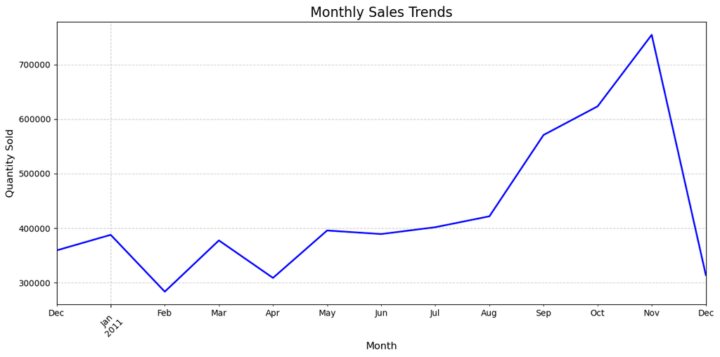

```python
# Convert InvoiceDate to datetime if not already
data['InvoiceDate'] = pd.to_datetime(data['InvoiceDate'])

# Aggregate sales by month
data['Month'] = data['InvoiceDate'].dt.to_period('M')
monthly_sales = data.groupby('Month')['Quantity'].sum()

# Plot sales over time
plt.figure(figsize=(12, 6))
monthly_sales.plot(kind='line', linewidth=2, color='blue')
plt.title('Monthly Sales Trends', fontsize=16)
plt.xlabel('Month', fontsize=12)
plt.ylabel('Quantity Sold', fontsize=12)
plt.grid(True, linestyle='--', alpha=0.6)
plt.xticks(rotation=45, fontsize=10)
plt.yticks(fontsize=10)
plt.tight_layout()
plt.show()
```

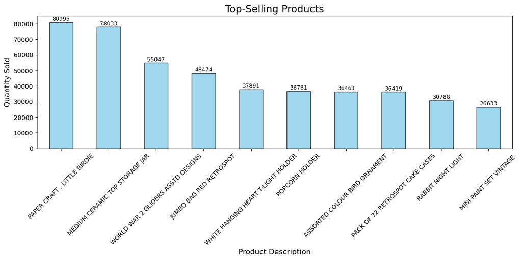

```python
# Aggregate sales by product
top_products = data.groupby('Description')['Quantity'].sum().sort_values(ascending=False).head(10)

# # Plot top products
plt.figure(figsize=(12, 6))
top_products.plot(kind='bar', color='skyblue', alpha=0.8, edgecolor='black')
plt.title('Top-Selling Products', fontsize=16)
plt.xlabel('Product Description', fontsize=12)
plt.ylabel('Quantity Sold', fontsize=12)
plt.xticks(rotation=45, fontsize=10)

# Add data labels
for i, value in enumerate(top_products):
    plt.text(i, value + 1000, str(value), ha='center', fontsize=9, color='black')

plt.tight_layout()
plt.show()
```

We knew this was a UK dataset and this graph is confirmation.

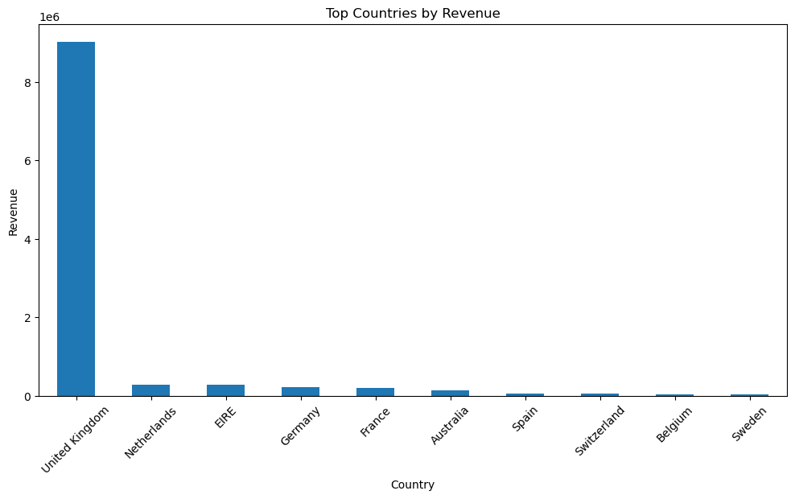

```python
# Calculate total revenue by country
data['Revenue'] = data['Quantity'] * data['UnitPrice']
country_revenue = data.groupby('Country')['Revenue'].sum().sort_values(ascending=False).head(10)

# Plot revenue by country
plt.figure(figsize=(12, 6))
country_revenue.plot(kind='bar', title='Top Countries by Revenue', ylabel='Revenue')
plt.xticks(rotation=45)
plt.show()
```

```python
data.groupby('CustomerID')['InvoiceNo'].nunique().describe() # number unique transactions per customer
```

```
count    4338.000000
mean        4.272015
std         7.697998
min         1.000000
25%         1.000000
50%         2.000000
75%         5.000000
max       209.000000
Name: InvoiceNo, dtype: float64
```

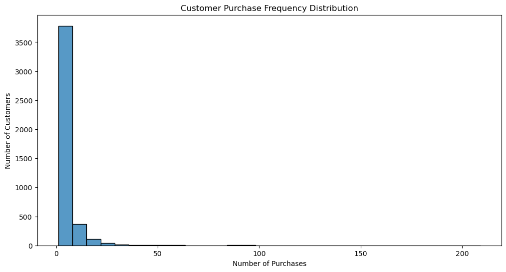

```python
# Calculate frequency of purchases per customer
customer_frequency = data.groupby('CustomerID')['InvoiceNo'].nunique() # number unique transactions per customer

# Plot frequency distribution
plt.figure(figsize=(12, 6))
sns.histplot(customer_frequency, bins=30, kde=False)
plt.title('Customer Purchase Frequency Distribution')
plt.xlabel('Number of Purchases')
plt.ylabel('Number of Customers')
plt.show();
```

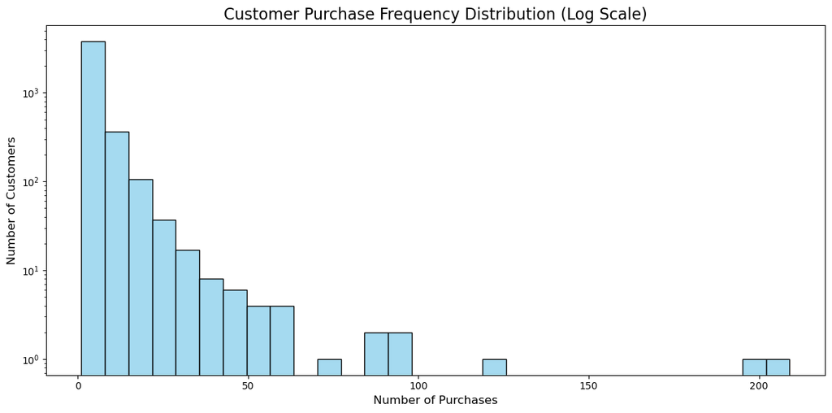

```python
plt.figure(figsize=(12, 6))
sns.histplot(customer_frequency, bins=30, kde=False, color='skyblue', edgecolor='black')
plt.title('Customer Purchase Frequency Distribution (Log Scale)', fontsize=16)
plt.xlabel('Number of Purchases', fontsize=12)
plt.ylabel('Number of Customers', fontsize=12)
plt.yscale('log')  # Apply log scale to the y-axis
plt.tight_layout()
plt.show()
```

```python
data.groupby('InvoiceNo')['Quantity'].sum().describe() # number unique transactions per customer
```

```
count    19960.000000
mean       279.978758
std        955.324779
min          1.000000
25%         70.000000
50%        151.000000
75%        296.000000
max      80995.000000
Name: Quantity, dtype: float64
```

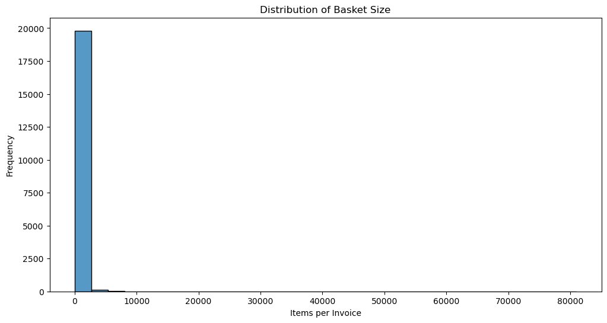

```python
# Calculate basket size per invoice
basket_size = data.groupby('InvoiceNo')['Quantity'].sum()

# Plot distribution of basket size
plt.figure(figsize=(12, 6))
sns.histplot(basket_size, bins=30, kde=False)
plt.title('Distribution of Basket Size')
plt.xlabel('Items per Invoice')
plt.ylabel('Frequency')
plt.show()
```

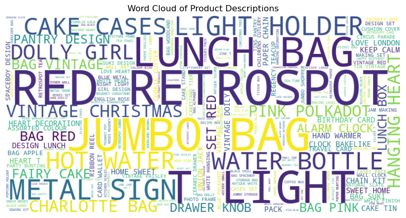

```python
from wordcloud import WordCloud

# Combine all product descriptions into a single string
text = ' '.join(data['Description'].dropna())

# Generate word cloud
wordcloud = WordCloud(width=800, height=400, background_color='white').generate(text)

# Display the word cloud
plt.figure(figsize=(10, 5))
plt.imshow(wordcloud, interpolation='bilinear')
plt.axis('off')
plt.title('Word Cloud of Product Descriptions')
plt.show()
```

```python
# Cast CustomerID as an object
data['CustomerID'] = data['CustomerID'].astype('object')

# Verify the change
print(data.dtypes)
```

```
InvoiceNo              object
StockCode              object
Description            object
Quantity                int64
InvoiceDate    datetime64[ns]
UnitPrice             float64
CustomerID             object
Country                object
Month               period[M]
Revenue               float64
dtype: object
```

```python
# Check for missing values
print(data.isnull().sum())
```

```
InvoiceNo           0
StockCode           0
Description         0
Quantity            0
InvoiceDate         0
UnitPrice           0
CustomerID     132220
Country             0
Month               0
Revenue             0
dtype: int64
```

## Step 4: Feature Engineering

```python
# Drop rows with missing CustomerID
data = data.dropna(subset=['CustomerID'])

# Display dataset information
print(data.shape)
data.info()
```

```
(397884, 10)
<class 'pandas.core.frame.DataFrame'>
Index: 397884 entries, 0 to 541908
Data columns (total 10 columns):
 #   Column       Non-Null Count   Dtype
---  ------       --------------   -----
 0   InvoiceNo    397884 non-null  object
 1   StockCode    397884 non-null  object
 2   Description  397884 non-null  object
 3   Quantity     397884 non-null  int64
 4   InvoiceDate  397884 non-null  datetime64[ns]
 5   UnitPrice    397884 non-null  float64
 6   CustomerID   397884 non-null  object
 7   Country      397884 non-null  object
 8   Month        397884 non-null  period[M]
 9   Revenue      397884 non-null  float64
dtypes: datetime64[ns](1), float64(2), int64(1), object(5), period[M](1)
memory usage: 33.4+ MB
```

```python
# Create Recency, Frequency, and Monetary (RFM) features
import datetime as dt

# Define a reference date for recency calculation
reference_date = data['InvoiceDate'].max() + dt.timedelta(days=1)

# Aggregate data at the customer level
rfm = data.groupby('CustomerID').agg({
    'InvoiceDate': lambda x: (reference_date - x.max()).days,  # Recency
    'InvoiceNo': 'count',  # Frequency
    'Quantity': lambda x: (x * data.loc[x.index, 'UnitPrice']).sum()  # Monetary
}).rename(columns={'InvoiceDate': 'Recency', 'InvoiceNo': 'Frequency', 'Quantity': 'Monetary'})

# Display RFM dataset
rfm.head()
```

| CustomerID | Recency | Frequency | Monetary |
| --- | --- | --- | --- |
| 12346.0 | 326 | 1 | 77183.60 |
| 12347.0 | 2 | 182 | 4310.00 |
| 12348.0 | 75 | 31 | 1797.24 |
| 12349.0 | 19 | 73 | 1757.55 |
| 12350.0 | 310 | 17 | 334.40 |

## Step 5: Data Preprocessing

```python
# Log-transform monetary values to reduce skewness
rfm['Monetary'] = np.log1p(rfm['Monetary'])

# Standardize features
scaler = StandardScaler()
rfm_scaled = scaler.fit_transform(rfm)

# Convert back to a DataFrame for readability
rfm_scaled = pd.DataFrame(rfm_scaled, columns=rfm.columns, index=rfm.index)
rfm_scaled.head()
```

| CustomerID | Recency | Frequency | Monetary |
| --- | --- | --- | --- |
| 12346.0 | 2.334574 | -0.396578 | 3.706225 |
| 12347.0 | -0.905340 | 0.394649 | 1.411843 |
| 12348.0 | -0.175360 | -0.265435 | 0.716489 |
| 12349.0 | -0.735345 | -0.081836 | 0.698739 |
| 12350.0 | 2.174578 | -0.326635 | -0.618962 |

## Step 6: Clustering with K-Means

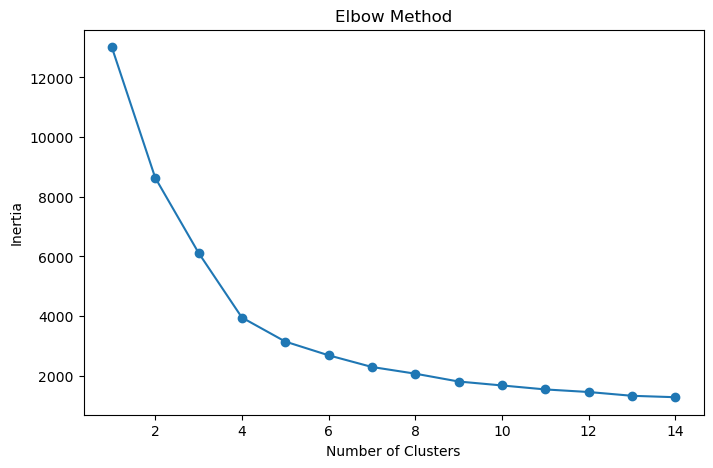

```python
# Determine the optimal number of clusters using the Elbow Method
inertia = []
for k in range(1, 15):
    kmeans = KMeans(n_clusters=k, random_state=512, n_init='auto')
    kmeans.fit(rfm_scaled)
    inertia.append(kmeans.inertia_)

# Plot the Elbow Curve
plt.figure(figsize=(8, 5))
plt.plot(range(1, 15), inertia, marker='o')
plt.xlabel('Number of Clusters')
plt.ylabel('Inertia')
plt.title('Elbow Method')
plt.show()
```

```python
# Fit K-Means with the optimal number of clusters
optimal_k = 7  # Replace this with the optimal number based on the elbow curve
kmeans = KMeans(n_clusters=optimal_k, random_state=512, n_init='auto')
rfm['Cluster'] = kmeans.fit_predict(rfm_scaled)

# Display cluster counts
rfm['Cluster'].value_counts()
```

```
Cluster
5    1420
3     953
0     716
1     603
6     592
4      50
2       4
Name: count, dtype: int64
```

## Step 7: Visualize Clusters

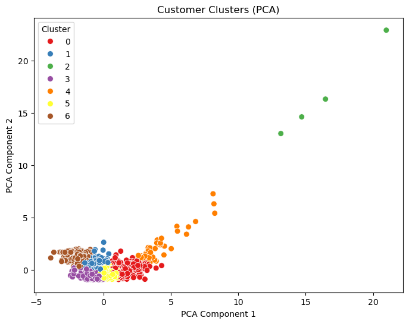

```python
# Reduce dimensions for visualization
pca = PCA(n_components=2)
rfm_pca = pca.fit_transform(rfm_scaled)

# Plot the clusters
plt.figure(figsize=(8, 6))
sns.scatterplot(x=rfm_pca[:, 0], y=rfm_pca[:, 1], hue=rfm['Cluster'], palette='Set1', s=50)
plt.title('Customer Clusters (PCA)')
plt.xlabel('PCA Component 1')
plt.ylabel('PCA Component 2')
plt.legend(title='Cluster')
plt.show()
```

## Step 8: Cluster Profiling

```python
# Profile each cluster
cluster_summary = rfm.groupby('Cluster').mean()
cluster_summary['Count'] = rfm['Cluster'].value_counts()
cluster_summary
```

| Cluster | Recency | Frequency | Monetary | Count |
| --- | --- | --- | --- | --- |
| 0 | 26.266760 | 225.317039 | 8.394856 | 716 |
| 1 | 178.598673 | 40.058043 | 6.311468 | 603 |
| 2 | 2.000000 | 5807.000000 | 11.002016 | 4 |
| 3 | 49.814271 | 24.174187 | 5.446517 | 953 |
| 4 | 8.720000 | 989.120000 | 9.322609 | 50 |
| 5 | 38.331690 | 74.404930 | 6.984003 | 1420 |
| 6 | 291.508446 | 18.623311 | 5.352481 | 592 |

```python
cluster_summary.to_dict()
```

```
{'Recency': {0: 26.26675977653631,
  1: 178.59867330016584,
  2: 2.0,
  3: 49.81427072402938,
  4: 8.72,
  5: 38.33169014084507,
  6: 291.50844594594594},
 'Frequency': {0: 225.31703910614524,
  1: 40.05804311774461,
  2: 5807.0,
  3: 24.174186778593914,
  4: 989.12,
  5: 74.40492957746478,
  6: 18.62331081081081},
 'Monetary': {0: 8.39485610281252,
  1: 6.311468142060303,
  2: 11.002016004810551,
  3: 5.446516718279689,
  4: 9.322608947834658,
  5: 6.984003379776276,
  6: 5.352480632086254},
 'Count': {0: 716, 1: 603, 2: 4, 3: 953, 4: 50, 5: 1420, 6: 592}}
```

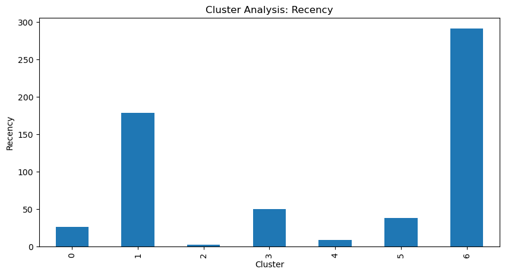

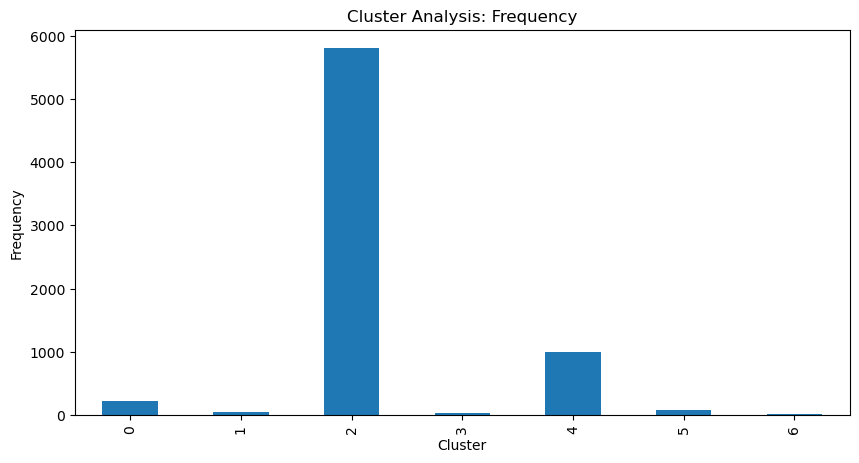

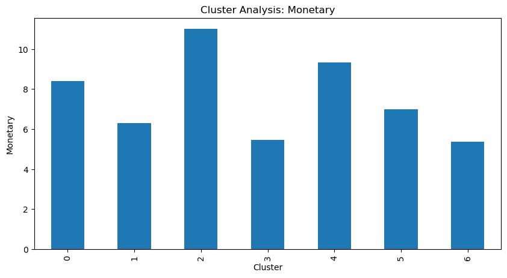

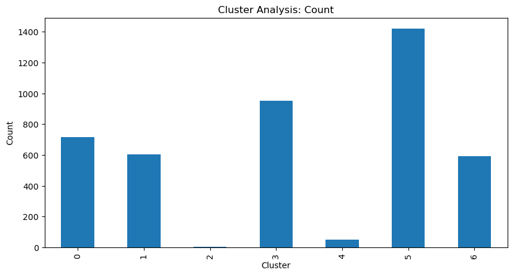

```python
import matplotlib.pyplot as plt

# Data for plotting
cluster_summary = rfm.groupby('Cluster').mean()
cluster_summary['Count'] = rfm['Cluster'].value_counts()

# Plot each feature
features = ['Recency', 'Frequency', 'Monetary', 'Count']
for feature in features:
    cluster_summary[feature].plot(kind='bar', figsize=(10, 5), title=f"Cluster Analysis: {feature}", ylabel=feature)
    plt.show()
```

### Cluster Descriptions Based on the Data

#### **Cluster 0: Loyal High-Frequency Customers**

- **Recency**: 26.27 (active within the last month).
- **Frequency**: 225.32 transactions (frequent shoppers).
- **Monetary**: 8.39 (moderately high spenders).
- **Count**: 716 customers.
- **Insights**:
  - These are loyal customers who shop frequently and spend a significant amount.
- **Actionable Strategy**:
  - Use loyalty programs and personalized promotions to retain and further engage these customers.

#### **Cluster 1: Dormant Moderate Spenders**

- **Recency**: 178.60 (inactive for ~6 months).
- **Frequency**: 40.06 transactions (moderate shopping frequency).
- **Monetary**: 6.31 (moderate spenders).
- **Count**: 603 customers.
- **Insights**:
  - These customers are at risk of churn.
- **Actionable Strategy**:
  - Reactivate them with targeted offers, such as discounts or email campaigns.

#### **Cluster 2: VIP High-Spending Customers**

- **Recency**: 2.00 (very recently active).
- **Frequency**: 5807.00 transactions (extremely frequent shoppers).
- **Monetary**: 11.00 (very high spenders).
- **Count**: 4 customers.
- **Insights**:
  - These are your most valuable customers who contribute significantly to revenue.
- **Actionable Strategy**:
  - Provide VIP treatment, such as exclusive services, personalized offers, and early access to products.

#### **Cluster 3: Infrequent Low-Value Customers**

- **Recency**: 49.81 (somewhat recently active).
- **Frequency**: 24.17 transactions (low shopping frequency).
- **Monetary**: 5.45 (low spenders).
- **Count**: 953 customers.
- **Insights**:
  - These customers are low-value and shop infrequently.
- **Actionable Strategy**:
  - Offer discounts or bundles to encourage more frequent shopping.

#### **Cluster 4: Elite High-Frequency Customers**

- **Recency**: 8.72 (very recently active).
- **Frequency**: 989.12 transactions (very frequent shoppers).
- **Monetary**: 9.32 (high spenders).
- **Count**: 50 customers.
- **Insights**:
  - This elite group shops frequently and spends a significant amount.
- **Actionable Strategy**:
  - Engage them with premium products, loyalty rewards, and exclusive promotions.

#### **Cluster 6: Lapsed Low-Value Customers**

- **Recency**: 291.51 (inactive for ~10 months).
- **Frequency**: 18.62 transactions (low shopping frequency).
- **Monetary**: 5.35 (low spenders).
- **Count**: 592 customers.
- **Insights**:
  - These customers are at high risk of churn and contribute minimally to revenue.
- **Actionable Strategy**:
  - Use strong incentives, such as deep discounts, to win them back.

## Step 10: Insights and Recommendations

### Key Observations

```python
rfm[rfm.Cluster==4]
```

| CustomerID | Recency | Frequency | Monetary | Cluster |
| --- | --- | --- | --- | --- |
| 12415.0 | 24 | 714 | 11.735393 | 4 |
| 12681.0 | 15 | 638 | 9.531593 | 4 |
| 12921.0 | 9 | 720 | 9.716440 | 4 |
| 13081.0 | 12 | 1024 | 10.251972 | 4 |
| 13089.0 | 3 | 1818 | 10.982353 | 4 |
| 13098.0 | 1 | 572 | 10.271024 | 4 |
| 13137.0 | 11 | 704 | 8.202869 | 4 |
| 13263.0 | 1 | 1677 | 8.916650 | 4 |
| 13694.0 | 4 | 568 | 11.082767 | 4 |
| 13969.0 | 7 | 626 | 9.111066 | 4 |
| 14056.0 | 1 | 1106 | 9.013796 | 4 |
| 14088.0 | 10 | 589 | 10.829586 | 4 |
| 14156.0 | 10 | 1400 | 11.673177 | 4 |
| 14159.0 | 20 | 1204 | 8.454043 | 4 |
| 14298.0 | 8 | 1637 | 10.849886 | 4 |
| 14456.0 | 5 | 970 | 8.027281 | 4 |
| 14505.0 | 17 | 799 | 8.683832 | 4 |
| 14527.0 | 3 | 972 | 9.048976 | 4 |
| 14606.0 | 1 | 2700 | 9.405714 | 4 |
| 14646.0 | 2 | 2076 | 12.543284 | 4 |
| 14769.0 | 3 | 1090 | 9.275730 | 4 |
| 14796.0 | 1 | 1141 | 8.990129 | 4 |
| 15005.0 | 16 | 1119 | 8.751090 | 4 |
| 15039.0 | 10 | 1502 | 9.899251 | 4 |
| 15159.0 | 2 | 710 | 9.833173 | 4 |
| 15311.0 | 1 | 2379 | 11.014833 | 4 |
| 15529.0 | 23 | 672 | 8.293107 | 4 |
| 15547.0 | 7 | 702 | 8.508322 | 4 |
| 15555.0 | 12 | 899 | 8.477656 | 4 |
| 15719.0 | 33 | 937 | 8.526472 | 4 |
| 15856.0 | 4 | 645 | 9.704339 | 4 |
| 16033.0 | 6 | 1137 | 9.084482 | 4 |
| 16241.0 | 10 | 662 | 7.866672 | 4 |
| 16360.0 | 5 | 662 | 8.164377 | 4 |
| 16549.0 | 10 | 981 | 8.332222 | 4 |
| 16713.0 | 19 | 624 | 8.842768 | 4 |
| 16729.0 | 38 | 660 | 8.887504 | 4 |
| 16764.0 | 4 | 706 | 7.937464 | 4 |
| 16904.0 | 4 | 710 | 8.230915 | 4 |
| 16923.0 | 12 | 672 | 8.888565 | 4 |
| 16931.0 | 5 | 898 | 8.434946 | 4 |
| 17338.0 | 17 | 753 | 8.801609 | 4 |
| 17511.0 | 3 | 963 | 11.419311 | 4 |
| 17675.0 | 1 | 705 | 9.922078 | 4 |
| 17735.0 | 2 | 690 | 9.481208 | 4 |
| 17757.0 | 1 | 741 | 8.631644 | 4 |
| 17811.0 | 4 | 851 | 8.966832 | 4 |
| 17920.0 | 4 | 696 | 8.344053 | 4 |
| 18118.0 | 11 | 1279 | 8.640264 | 4 |
| 18283.0 | 4 | 756 | 7.647729 | 4 |